# 1. - Preparación de los datos para el tratamiento

### Análisis visual

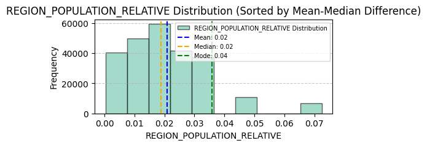

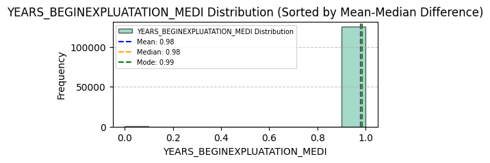

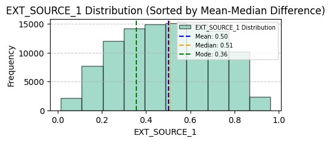

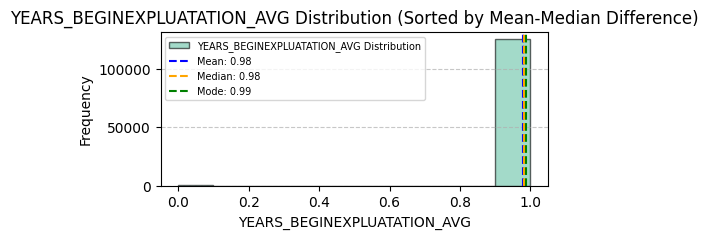

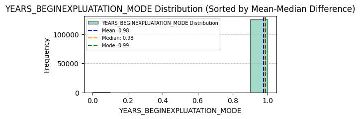

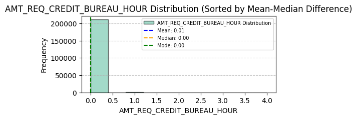

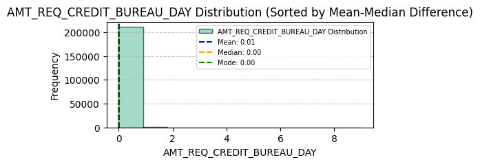

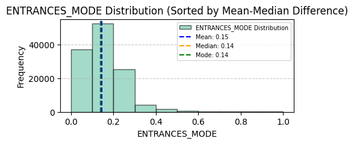

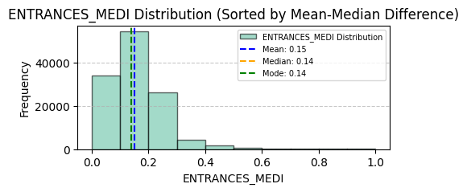

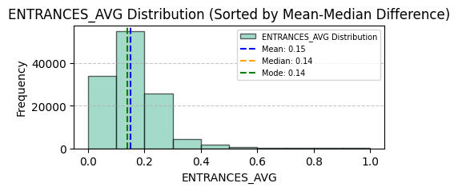

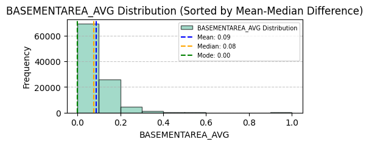

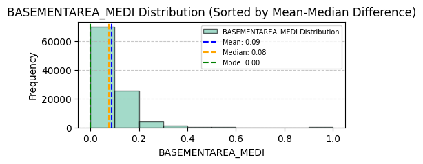

[43 more figures not shown]

```
({'REGION_POPULATION_RELATIVE': {'mean': 0.020865365097882983,
   'median': 0.01885,
   'mode': 0.035792},
  'YEARS_BEGINEXPLUATATION_MEDI': {'mean': 0.9778900161017825,
   'median': 0.9816,
   'mode': 0.9861},
  'EXT_SOURCE_1': {'mean': 0.5023142078923669,
   'median': 0.5061746945393781,
   'mode': 0.3563226644129184},
  'YEARS_BEGINEXPLUATATION_AVG': {'mean': 0.9778614302824553,
   'median': 0.9821,
   'mode': 0.9871},
  'YEARS_BEGINEXPLUATATION_MODE': {'mean': 0.9771838109666623,
   'median': 0.9816,
   'mode': 0.9871},
  'AMT_REQ_CREDIT_BUREAU_HOUR': {'mean': 0.006278895854988077,
   'median': 0.0,
   'mode': 0.0},
  'AMT_REQ_CREDIT_BUREAU_DAY': {'mean': 0.0070079062351552325,
   'median': 0.0,
   'mode': 0.0},
  'ENTRANCES_MODE': {'mean': 0.14532733072160564,
   'median': 0.1379,
   'mode': 0.1379},
  'ENTRANCES_MEDI': {'mean': 0.14937829212637713,
   'median': 0.1379,
   'mode': 0.1379},
  'ENTRANCES_AVG': {'mean': 0.14987947721826467,
   'median': 0.1379,
   'mode': 0.1379},
  'BASEMENTAREA_AVG': {'mean': 0.08847286444461851,
   'median': 0.0763,
   'mode': 0.0},
  'BASEMENTAREA_MEDI': {'mean': 0.08797465435531882,
   'median': 0.0758,
   'mode': 0.0},
  'BASEMENTAREA_MODE': {'mean': 0.08753542906940309,
   'median': 0.0746,
   'mode': 0.0},
  'LANDAREA_AVG': {'mean': 0.06636107582592345, 'median': 0.0481, 'mode': 0.0},
```

[output cut: 151 more lines]

```
  'FLOORSMAX_MEDI',
  'LANDAREA_MEDI',
  'LIVINGAREA_MEDI',
  'NONLIVINGAREA_MEDI',
  'TOTALAREA_MODE',
  'OBS_30_CNT_SOCIAL_CIRCLE',
  'DEF_30_CNT_SOCIAL_CIRCLE',
  'OBS_60_CNT_SOCIAL_CIRCLE',
  'DEF_60_CNT_SOCIAL_CIRCLE',
  'AMT_REQ_CREDIT_BUREAU_HOUR',
  'AMT_REQ_CREDIT_BUREAU_DAY',
  'AMT_REQ_CREDIT_BUREAU_WEEK',
  'AMT_REQ_CREDIT_BUREAU_MON',
  'AMT_REQ_CREDIT_BUREAU_QRT',
  'AMT_REQ_CREDIT_BUREAU_YEAR'])
```

```python
f.analyze_and_sort_columns(df_loan_train, lista_continuas)
```

## 2.2.2. - Tratamiento valores faltantes

Criterios principales para imputación:

1. Imputar con la media: Cuándo usarlo: La distribución es aproximadamente simétrica. La media representa bien el centro de la distribución sin ser influenciada por outliers extremos. Ventaja: Es simple y rápida. Desventaja: En distribuciones sesgadas, puede distorsionar los datos.
2. Imputar con la mediana: Cuándo usarlo: La distribución tiene un sesgo (asimetría) o hay valores atípicos (outliers) que afectan la media. La mediana es más robusta frente a valores extremos.
   - Ventaja: Mantiene la estructura central de datos sesgados.
   - Desventaja: No captura toda la variabilidad de la distribución.
3. Imputar con la moda: Cuándo usarlo: La variable es categórica o tiene una distribución con valores altamente repetidos. Es útil en datos discretos o donde un valor domina la distribución.
   - Ventaja: Mantiene el valor más frecuente en los datos.
   - Desventaja: No es adecuada para variables continuas.
4. Métodos avanzados:
   - Interpolación: Útil para datos secuenciales o temporales.
   - Imputación basada en predicción: Usar modelos como regresión, árboles de decisión, o k-NN para predecir valores faltantes.
   - MICE (Multiple Imputation by Chained Equations): Genera múltiples imputaciones y promedia los resultados.
   - KNN Imputation: Usa los valores más cercanos (según distancia euclidiana) para completar los faltantes.

```python
resultados, lista_media, lista_mediana = f.crear_lista_tratamiento(df_loan_train, lista_continuas, 25)
lista_mediana
```

```
['CNT_CHILDREN',
 'OWN_CAR_AGE',
 'APARTMENTS_AVG',
 'ELEVATORS_AVG',
 'FLOORSMAX_AVG',
 'LANDAREA_AVG',
 'LIVINGAREA_AVG',
 'NONLIVINGAREA_AVG',
 'APARTMENTS_MODE',
 'ELEVATORS_MODE',
 'FLOORSMAX_MODE',
 'LANDAREA_MODE',
 'LIVINGAREA_MODE',
 'NONLIVINGAREA_MODE',
 'APARTMENTS_MEDI',
 'ELEVATORS_MEDI',
 'FLOORSMAX_MEDI',
 'LANDAREA_MEDI',
 'LIVINGAREA_MEDI',
 'NONLIVINGAREA_MEDI',
 'TOTALAREA_MODE',
 'OBS_30_CNT_SOCIAL_CIRCLE',
 'DEF_30_CNT_SOCIAL_CIRCLE',
 'OBS_60_CNT_SOCIAL_CIRCLE',
 'DEF_60_CNT_SOCIAL_CIRCLE',
 'AMT_REQ_CREDIT_BUREAU_HOUR',
 'AMT_REQ_CREDIT_BUREAU_DAY',
 'AMT_REQ_CREDIT_BUREAU_WEEK',
 'AMT_REQ_CREDIT_BUREAU_MON',
 'AMT_REQ_CREDIT_BUREAU_QRT',
 'AMT_REQ_CREDIT_BUREAU_YEAR']
```

```python
lista_mediana= [elem for elem in lista_mediana if elem not in lista_KNN]
```

## 2.2.3. - Imputación de los valores

```python
from sklearn.impute import SimpleImputer

# Imputación por media, aquí lo voy a hacer de forma básica, usando un loop en vez de utilizar los métoodos
# específicos de sicit-learn, para ir viendo el funcionamiento
for i in lista_media:
    media = df_loan_train[i].mean()  # Calcular la media de la columna en el DataFrame de entrenamiento
    df_loan_train[i] = df_loan_train[i].fillna(media)  # Rellenar NaN en el DataFrame de entrenamiento
    df_loan_test[i] = df_loan_test[i].fillna(media)    # Rellenar NaN en el DataFrame de prueba


# Crear un imputador con la estrategia de la media
imputer = SimpleImputer(strategy='median')

# Con fit calculamos el valor del imputer y luego lo aplicamos, hay que hacerlo con el conjunto de
# entrenamiento
df_loan_train[lista_mediana] = imputer.fit_transform(df_loan_train[lista_mediana])
df_loan_test[lista_mediana] = imputer.transform(df_loan_test[lista_mediana])
```

```python
### Imputación con KNN
X_train_knn = df_loan_train[lista_KNN]
X_test_knn = df_loan_test[lista_KNN]

# Reducir el tamaño del conjunto para KNN -- sin esta parte me era imposible realizar el proceso
X_train_sample = X_train_knn.sample(frac=0.1, random_state=42)  # Usar solo el 10% de las filas
imputer_knn = KNNImputer(n_neighbors=2, weights="uniform")
model = imputer_knn.fit(X_train_sample)

# imputación de los valores en los conjuntos de datos
X_train_knn_imputed = imputer_knn.transform(X_train_knn)
X_test_knn_imputed = imputer_knn.transform(X_test_knn)
```

```python
# Crear DataFrames con las variables imputadas por KNN
df_knn_train = pd.DataFrame(X_train_knn_imputed,
                            columns=[f"{col}_input" for col in lista_KNN],
                            index=df_loan_train.index)
df_knn_test = pd.DataFrame(X_test_knn_imputed,
                           columns=[f"{col}_input" for col in lista_KNN],
                           index=df_loan_test.index)

# Concatenar resultados con los DataFrames originales y eliminar las variables originales imputadas por KNN
df_loan_imputed_train = pd.concat([df_loan_train, df_knn_train], axis=1).drop(lista_KNN, axis=1)
df_loan_imputed_test = pd.concat([df_loan_test, df_knn_test], axis=1).drop(lista_KNN, axis=1)
df_loan_imputed_train
```

|  | SK_ID_CURR | NAME_CONTRACT_TYPE | CODE_GENDER | FLAG_OWN_CAR | FLAG_OWN_REALTY | CNT_CHILDREN | AMT_INCOME_TOTAL | AMT_CREDIT | AMT_ANNUITY | AMT_GOODS_PRICE | NAME_TYPE_SUITE | NAME_INCOME_TYPE | NAME_EDUCATION_TYPE | NAME_FAMILY_STATUS | NAME_HOUSING_TYPE | REGION_POPULATION_RELATIVE | DAYS_BIRTH | DAYS_EMPLOYED | DAYS_REGISTRATION | DAYS_ID_PUBLISH | OWN_CAR_AGE | FLAG_MOBIL | FLAG_EMP_PHONE | FLAG_WORK_PHONE | FLAG_CONT_MOBILE | FLAG_PHONE | FLAG_EMAIL | OCCUPATION_TYPE | CNT_FAM_MEMBERS | … |
| --- | --- | --- | --- | --- | --- | --- | --- | --- | --- | --- | --- | --- | --- | --- | --- | --- | --- | --- | --- | --- | --- | --- | --- | --- | --- | --- | --- | --- | --- | --- |
| 305637 | 454112 | Cash loans | M | Y | Y | 0.0 | 135000.0 | 1061599.5 | 31171.5 | 927000.0 | Spouse, partner | Working | Secondary / secondary special | Married | House / apartment | 0.022625 | -18074 | -1102 | -7782.0 | -1615 | 9.0 | 1 | 1 | 1 | 1 | 1 | 0 | Drivers | 2.0 | … |
| 152596 | 276860 | Cash loans | M | N | Y | 0.0 | 216000.0 | 760131.0 | 28057.5 | 634500.0 | Unaccompanied | Working | Secondary / secondary special | Married | House / apartment | 0.028663 | -19562 | -6129 | -9254.0 | -3116 | 9.0 | 1 | 1 | 0 | 1 | 0 | 0 | Laborers | 2.0 | … |
| 64100 | 174331 | Cash loans | F | N | Y | 0.0 | 247500.0 | 675000.0 | 21906.0 | 675000.0 | Unaccompanied | Working | Secondary / secondary special | Married | House / apartment | 0.026392 | -15775 | -1294 | -9887.0 | -4038 | 9.0 | 1 | 1 | 0 | 1 | 0 | 0 | Security staff | 2.0 | … |
| 24351 | 128326 | Cash loans | M | N | Y | 0.0 | 189000.0 | 355536.0 | 18283.5 | 270000.0 | Unaccompanied | Working | Secondary / secondary special | Civil marriage | House / apartment | 0.010276 | -21145 | -13389 | -2294.0 | -4142 | 9.0 | 1 | 1 | 0 | 1 | 0 | 0 | Laborers | 2.0 | … |
| 118194 | 237052 | Cash loans | F | N | Y | 0.0 | 85500.0 | 99000.0 | 9774.0 | 99000.0 | Unaccompanied | Pensioner | Secondary / secondary special | Separated | House / apartment | 0.028663 | -22949 | 365243 | -398.0 | -4195 | 9.0 | 1 | 0 | 0 | 1 | 0 | 0 | NaN | 1.0 | … |
| ... | ... | ... | ... | ... | ... | ... | ... | ... | ... | ... | ... | ... | ... | ... | ... | ... | ... | ... | ... | ... | ... | ... | ... | ... | ... | ... | ... | ... | ... | … |
| 237178 | 374715 | Cash loans | F | N | Y | 0.0 | 270000.0 | 1102828.5 | 32373.0 | 963000.0 | Unaccompanied | Commercial associate | Secondary / secondary special | Married | House / apartment | 0.024610 | -16908 | -824 | -7633.0 | -454 | 9.0 | 1 | 1 | 0 | 1 | 0 | 0 | Laborers | 2.0 | … |
| 219203 | 353933 | Cash loans | F | Y | Y | 2.0 | 112500.0 | 135000.0 | 10444.5 | 135000.0 | Unaccompanied | Working | Higher education | Married | House / apartment | 0.006852 | -13590 | -2786 | -676.0 | -896 | 14.0 | 1 | 1 | 0 | 1 | 0 | 0 | Accountants | 4.0 | … |
| 145178 | 268346 | Cash loans | M | Y | Y | 2.0 | 279000.0 | 900000.0 | 35824.5 | 900000.0 | Spouse, partner | Commercial associate | Higher education | Married | House / apartment | 0.035792 | -13979 | -5930 | -1186.0 | -5996 | 5.0 | 1 | 1 | 1 | 1 | 1 | 0 | NaN | 4.0 | … |
| 236081 | 373444 | Cash loans | F | N | Y | 0.0 | 112500.0 | 450000.0 | 22018.5 | 450000.0 | Unaccompanied | Commercial associate | Secondary / secondary special | Married | House / apartment | 0.018209 | -10457 | -314 | -3762.0 | -730 | 9.0 | 1 | 1 | 0 | 1 | 1 | 0 | Laborers | 2.0 | … |
| 245426 | 384037 | Cash loans | F | N | N | 0.0 | 67500.0 | 167121.0 | 12015.0 | 139500.0 | Family | Working | Secondary / secondary special | Married | House / apartment | 0.022625 | -15661 | -5158 | -1513.0 | -4054 | 9.0 | 1 | 1 | 0 | 1 | 0 | 0 | Core staff | 2.0 | … |

246008 rows × 106 columns

```python
lista_knn_imputed = [col for col in df_loan_imputed_train.columns if col.startswith("AMT_REQ_CREDIT_BUREAU_")]
df_loan_imputed_train[lista_knn_imputed].head()
```

|  | AMT_REQ_CREDIT_BUREAU_HOUR_input | AMT_REQ_CREDIT_BUREAU_DAY_input | AMT_REQ_CREDIT_BUREAU_WEEK_input | AMT_REQ_CREDIT_BUREAU_MON_input | AMT_REQ_CREDIT_BUREAU_QRT_input | AMT_REQ_CREDIT_BUREAU_YEAR_input |
| --- | --- | --- | --- | --- | --- | --- |
| 305637 | 0.0 | 0.0 | 0.0 | 0.0 | 3.0 | 5.0 |
| 152596 | 0.0 | 0.0 | 0.0 | 0.0 | 0.0 | 1.0 |
| 64100 | 0.0 | 0.0 | 0.0 | 1.0 | 0.0 | 4.0 |
| 24351 | 0.0 | 0.0 | 0.0 | 0.0 | 0.0 | 1.0 |
| 118194 | 0.0 | 0.0 | 0.0 | 0.0 | 0.0 | 1.0 |

```python
## Actualizo la información para mis nuevas variables y mi nuevo 'df_loan_imputed_train/test'
lista_continuas_imputed = [col for col in lista_continuas if col not in lista_KNN]
lista_continuas_imputed.extend(lista_knn_imputed)
lista_continuas_imputed
```

```
['CNT_CHILDREN',
 'AMT_INCOME_TOTAL',
 'AMT_CREDIT',
 'AMT_ANNUITY',
 'AMT_GOODS_PRICE',
 'REGION_POPULATION_RELATIVE',
 'DAYS_BIRTH',
 'DAYS_EMPLOYED',
 'DAYS_REGISTRATION',
 'DAYS_ID_PUBLISH',
 'OWN_CAR_AGE',
 'CNT_FAM_MEMBERS',
 'HOUR_APPR_PROCESS_START',
 'EXT_SOURCE_1',
 'EXT_SOURCE_2',
 'EXT_SOURCE_3',
 'APARTMENTS_AVG',
 'BASEMENTAREA_AVG',
 'YEARS_BEGINEXPLUATATION_AVG',
 'ELEVATORS_AVG',
 'ENTRANCES_AVG',
 'FLOORSMAX_AVG',
 'LANDAREA_AVG',
 'LIVINGAREA_AVG',
 'NONLIVINGAREA_AVG',
 'APARTMENTS_MODE',
 'BASEMENTAREA_MODE',
 'YEARS_BEGINEXPLUATATION_MODE',
 'ELEVATORS_MODE',
 'ENTRANCES_MODE',
 'FLOORSMAX_MODE',
 'LANDAREA_MODE',
 'LIVINGAREA_MODE',
 'NONLIVINGAREA_MODE',
 'APARTMENTS_MEDI',
 'BASEMENTAREA_MEDI',
 'YEARS_BEGINEXPLUATATION_MEDI',
 'ELEVATORS_MEDI',
 'ENTRANCES_MEDI',
 'FLOORSMAX_MEDI',
 'LANDAREA_MEDI',
 'LIVINGAREA_MEDI',
 'NONLIVINGAREA_MEDI',
 'TOTALAREA_MODE',
 'OBS_30_CNT_SOCIAL_CIRCLE',
 'DEF_30_CNT_SOCIAL_CIRCLE',
 'OBS_60_CNT_SOCIAL_CIRCLE',
 'DEF_60_CNT_SOCIAL_CIRCLE',
 'DAYS_LAST_PHONE_CHANGE',
 'AMT_REQ_CREDIT_BUREAU_HOUR_input',
 'AMT_REQ_CREDIT_BUREAU_DAY_input',
 'AMT_REQ_CREDIT_BUREAU_WEEK_input',
 'AMT_REQ_CREDIT_BUREAU_MON_input',
 'AMT_REQ_CREDIT_BUREAU_QRT_input',
 'AMT_REQ_CREDIT_BUREAU_YEAR_input']
```

## 2.2.3. - Correlaciones variables continuas

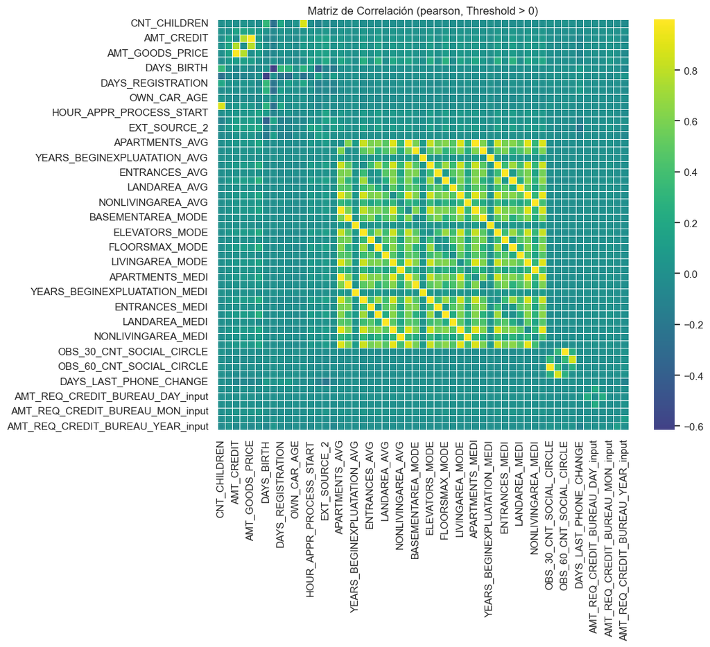

```
0
```

```python
f.get_corr_matrix(dataset = df_loan_imputed_train[lista_continuas_imputed],
                metodo='pearson', size_figure=[10,8])
```

```python
corr = df_loan_imputed_train[lista_continuas_imputed].corr('pearson')
new_corr = corr.abs()
new_corr.loc[:,:] = np.tril(new_corr, k=-1) # below main lower triangle of an array
new_corr = new_corr.stack().to_frame('correlation').reset_index().sort_values(by='correlation', ascending=False)
new_corr[new_corr['correlation']>0.7]
```

|  | level_0 | level_1 | correlation |
| --- | --- | --- | --- |
| 2574 | OBS_60_CNT_SOCIAL_CIRCLE | OBS_30_CNT_SOCIAL_CIRCLE | 0.998502 |
| 2166 | FLOORSMAX_MEDI | FLOORSMAX_AVG | 0.997360 |
| 2110 | ENTRANCES_MEDI | ENTRANCES_AVG | 0.996948 |
| 2054 | ELEVATORS_MEDI | ELEVATORS_AVG | 0.996613 |
| 2278 | LIVINGAREA_MEDI | LIVINGAREA_AVG | 0.995645 |
| 1886 | APARTMENTS_MEDI | APARTMENTS_AVG | 0.995446 |
| 1942 | BASEMENTAREA_MEDI | BASEMENTAREA_AVG | 0.994035 |
| 1998 | YEARS_BEGINEXPLUATATION_MEDI | YEARS_BEGINEXPLUATATION_AVG | 0.993125 |
| 2334 | NONLIVINGAREA_MEDI | NONLIVINGAREA_AVG | 0.992196 |
| 2222 | LANDAREA_MEDI | LANDAREA_AVG | 0.991845 |
| 2175 | FLOORSMAX_MEDI | FLOORSMAX_MODE | 0.988974 |
| 1671 | FLOORSMAX_MODE | FLOORSMAX_AVG | 0.986634 |
| 222 | AMT_GOODS_PRICE | AMT_CREDIT | 0.986632 |
| 2063 | ELEVATORS_MEDI | ELEVATORS_MODE | 0.985214 |
| 1559 | ELEVATORS_MODE | ELEVATORS_AVG | 0.981701 |
| 2231 | LANDAREA_MEDI | LANDAREA_MODE | 0.981355 |
| 2119 | ENTRANCES_MEDI | ENTRANCES_MODE | 0.980273 |
| 1895 | APARTMENTS_MEDI | APARTMENTS_MODE | 0.977966 |
| 1615 | ENTRANCES_MODE | ENTRANCES_AVG | 0.977388 |
| 2343 | NONLIVINGAREA_MEDI | NONLIVINGAREA_MODE | 0.977066 |
| 1951 | BASEMENTAREA_MEDI | BASEMENTAREA_MODE | 0.976871 |
| 2287 | LIVINGAREA_MEDI | LIVINGAREA_MODE | 0.976022 |
| 1391 | APARTMENTS_MODE | APARTMENTS_AVG | 0.974304 |
| 1727 | LANDAREA_MODE | LANDAREA_AVG | 0.973946 |
| 1783 | LIVINGAREA_MODE | LIVINGAREA_AVG | 0.973355 |
| 1447 | BASEMENTAREA_MODE | BASEMENTAREA_AVG | 0.972080 |
| 1503 | YEARS_BEGINEXPLUATATION_MODE | YEARS_BEGINEXPLUATATION_AVG | 0.970327 |
| 1839 | NONLIVINGAREA_MODE | NONLIVINGAREA_AVG | 0.969250 |
| 2007 | YEARS_BEGINEXPLUATATION_MEDI | YEARS_BEGINEXPLUATATION_MODE | 0.960662 |
| 2388 | TOTALAREA_MODE | LIVINGAREA_AVG | 0.917205 |
| 2406 | TOTALAREA_MODE | LIVINGAREA_MEDI | 0.912308 |
| 2289 | LIVINGAREA_MEDI | APARTMENTS_MEDI | 0.899663 |
| 1281 | LIVINGAREA_AVG | APARTMENTS_AVG | 0.897556 |
| 1893 | APARTMENTS_MEDI | LIVINGAREA_AVG | 0.896513 |
| 2271 | LIVINGAREA_MEDI | APARTMENTS_AVG | 0.896473 |
| 1785 | LIVINGAREA_MODE | APARTMENTS_MODE | 0.893605 |
| 2397 | TOTALAREA_MODE | LIVINGAREA_MODE | 0.893080 |
| 2381 | TOTALAREA_MODE | APARTMENTS_AVG | 0.882677 |
| 1902 | APARTMENTS_MEDI | LIVINGAREA_MODE | 0.880307 |
| 605 | CNT_FAM_MEMBERS | CNT_CHILDREN | 0.879177 |
| 2280 | LIVINGAREA_MEDI | APARTMENTS_MODE | 0.879032 |
| 1776 | LIVINGAREA_MODE | APARTMENTS_AVG | 0.878025 |
| 2399 | TOTALAREA_MODE | APARTMENTS_MEDI | 0.877188 |
| 1398 | APARTMENTS_MODE | LIVINGAREA_AVG | 0.875832 |
| 2630 | DEF_60_CNT_SOCIAL_CIRCLE | DEF_30_CNT_SOCIAL_CIRCLE | 0.861179 |
| 2390 | TOTALAREA_MODE | APARTMENTS_MODE | 0.855781 |
| 2292 | LIVINGAREA_MEDI | ELEVATORS_MEDI | 0.850447 |
| 1284 | LIVINGAREA_AVG | ELEVATORS_AVG | 0.848830 |
| 2058 | ELEVATORS_MEDI | LIVINGAREA_AVG | 0.847741 |
| 2274 | LIVINGAREA_MEDI | ELEVATORS_AVG | 0.847569 |
| 2283 | LIVINGAREA_MEDI | ELEVATORS_MODE | 0.840089 |
| 1788 | LIVINGAREA_MODE | ELEVATORS_MODE | 0.838781 |
| 1563 | ELEVATORS_MODE | LIVINGAREA_AVG | 0.836772 |
| 2384 | TOTALAREA_MODE | ELEVATORS_AVG | 0.836354 |
| 2402 | TOTALAREA_MODE | ELEVATORS_MEDI | 0.831323 |
| 2067 | ELEVATORS_MEDI | LIVINGAREA_MODE | 0.824757 |
| 2069 | ELEVATORS_MEDI | APARTMENTS_MEDI | 0.824361 |
| 1061 | ELEVATORS_AVG | APARTMENTS_AVG | 0.823149 |
| 1779 | LIVINGAREA_MODE | ELEVATORS_AVG | 0.822465 |
| 2051 | ELEVATORS_MEDI | APARTMENTS_AVG | 0.822135 |
| 1889 | APARTMENTS_MEDI | ELEVATORS_AVG | 0.821373 |
| 2393 | TOTALAREA_MODE | ELEVATORS_MODE | 0.817061 |
| 1565 | ELEVATORS_MODE | APARTMENTS_MODE | 0.815079 |
| 1898 | APARTMENTS_MEDI | ELEVATORS_MODE | 0.814670 |
| 1556 | ELEVATORS_MODE | APARTMENTS_AVG | 0.811722 |
| 2060 | ELEVATORS_MEDI | APARTMENTS_MODE | 0.798858 |
| 1394 | APARTMENTS_MODE | ELEVATORS_AVG | 0.795918 |
| 223 | AMT_GOODS_PRICE | AMT_ANNUITY | 0.775270 |
| 167 | AMT_ANNUITY | AMT_CREDIT | 0.770678 |
| 1174 | FLOORSMAX_AVG | ELEVATORS_AVG | 0.708948 |
| 2164 | FLOORSMAX_MEDI | ELEVATORS_AVG | 0.706520 |
| 2056 | ELEVATORS_MEDI | FLOORSMAX_AVG | 0.705624 |
| 2182 | FLOORSMAX_MEDI | ELEVATORS_MEDI | 0.704706 |

En el DataFrame presentado, se observa una fuerte correlación entre variables que comparten sufijos como _MODE, _AVG y _MEDI. Estas columnas representan diferentes formas de agregación o medición de características similares. Por ejemplo, variables como OBS_60_CNT_SOCIAL_CIRCLE y OBS_30_CNT_SOCIAL_CIRCLE o FLOORSMAX_MEDI y FLOORSMAX_AVG presentan correlaciones extremadamente altas, cercanas al 1.

Este nivel de redundancia dificulta la extracción de conclusiones claras, ya que las variables no aportan información verdaderamente independiente al análisis. Cuando múltiples variables contienen datos casi idénticos, es posible que los modelos predictivos o estadísticos asignen pesos similares a estas columnas, lo que puede llevar a problemas como multicolinealidad o sobreajuste.

Además, trabajar con estas variables sin una adecuada agrupación o reducción dimensional podría complicar la interpretación de los resultados y generar modelos más complejos de lo necesario. Por lo tanto, es esencial agrupar estas variables según sus sufijos (_MODE, _AVG, _MEDI) o seleccionar una representación representativa de cada grupo, para simplificar el análisis y evitar redundancias innecesarias.

```python
# Paso 1: Listar las columnas que no terminan en _MODE, _AVG o _MEDI
suffixes = ['_MODE', '_AVG', '_MEDI']
variables_resto = [col for col in df_loan_imputed_train[lista_continuas_imputed].columns if not any(col.endswith(suffix) for suffix in suffixes)]
print(variables_resto)
```

```
['CNT_CHILDREN', 'AMT_INCOME_TOTAL', 'AMT_CREDIT', 'AMT_ANNUITY', 'AMT_GOODS_PRICE', 'REGION_POPULATION_RELATIVE', 'DAYS_BIRTH', 'DAYS_EMPLOYED', 'DAYS_REGISTRATION', 'DAYS_ID_PUBLISH', 'OWN_CAR_AGE', 'CNT_FAM_MEMBERS', 'HOUR_APPR_PROCESS_START', 'EXT_SOURCE_1', 'EXT_SOURCE_2', 'EXT_SOURCE_3', 'OBS_…
```

```python
# Paso 2: Crear DataFrames separados para cada sufijo
mode_columns = [col for col in df_loan_imputed_train[lista_continuas_imputed].columns if col.endswith('_MODE')]
avg_columns = [col for col in df_loan_imputed_train[lista_continuas_imputed].columns if col.endswith('_AVG')]
medi_columns = [col for col in df_loan_imputed_train[lista_continuas_imputed].columns if col.endswith('_MEDI')]

# Crear un diccionario para almacenar los DataFrames con nombres específicos
dfs = {}

# Lista de sufijos y nombres correspondientes
df_names = ['df_mode', 'df_avg', 'df_medi']

# Crear los DataFrames combinando las variables restantes con las de cada sufijo
for name, suffix_columns in zip(df_names, [mode_columns, avg_columns, medi_columns]):
    varsi = variables_resto + suffix_columns  # Combinar las columnas sin sufijo con las del sufijo actual
    dfs[name] = df_loan_imputed_train[varsi]  # Guardar el DataFrame con el nombre específico

# Asignar los DataFrames a variables específicas
df_mode = dfs['df_mode']
df_avg = dfs['df_avg']
df_medi = dfs['df_medi']

# Verificar los DataFrames creados
print("DataFrame con '_MODE':", df_mode.head())
print("DataFrame con '_AVG':", df_avg.head())
print("DataFrame con '_MEDI':", df_medi.head())
```

```
DataFrame con '_MODE':         CNT_CHILDREN  AMT_INCOME_TOTAL  AMT_CREDIT  AMT_ANNUITY  \
305637           0.0          135000.0   1061599.5      31171.5
152596           0.0          216000.0    760131.0      28057.5
64100            0.0          247500.0    675000.0      21906.0
24351            0.0          189000.0    355536.0      18283.5
118194           0.0           85500.0     99000.0       9774.0

        AMT_GOODS_PRICE  REGION_POPULATION_RELATIVE  DAYS_BIRTH  \
305637         927000.0                    0.022625      -18074
152596         634500.0                    0.028663      -19562
64100          675000.0                    0.026392      -15775
24351          270000.0                    0.010276      -21145
118194          99000.0                    0.028663      -22949

        DAYS_EMPLOYED  DAYS_REGISTRATION  DAYS_ID_PUBLISH  OWN_CAR_AGE  \
```

[output cut: 241 more lines]

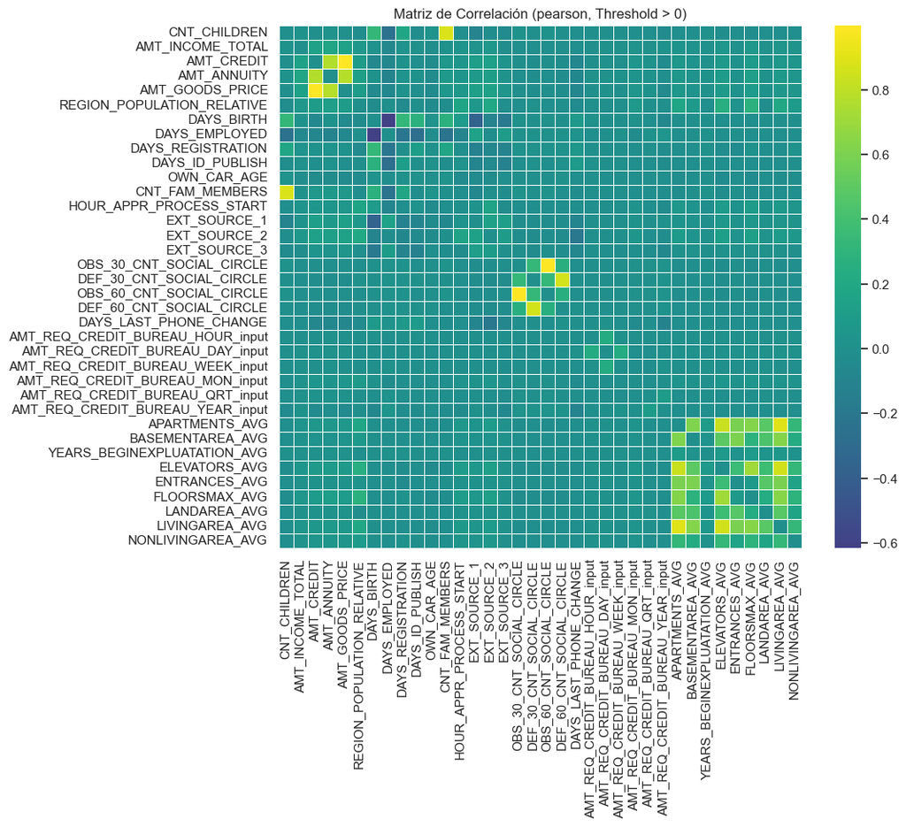

```
0
```

```python
f.get_corr_matrix(dataset = df_avg,
                metodo='pearson', size_figure=[10,8])
```

```python
corr = df_avg.corr('pearson')
new_corr = corr.abs()
new_corr.loc[:,:] = np.tril(new_corr, k=-1) # below main lower triangle of an array
new_corr = new_corr.stack().to_frame('correlation').reset_index().sort_values(by='correlation', ascending=False)
new_corr[new_corr['correlation']>0.6]
```

|  | level_0 | level_1 | correlation |
| --- | --- | --- | --- |
| 664 | OBS_60_CNT_SOCIAL_CIRCLE | OBS_30_CNT_SOCIAL_CIRCLE | 0.998502 |
| 146 | AMT_GOODS_PRICE | AMT_CREDIT | 0.986632 |
| 1251 | LIVINGAREA_AVG | APARTMENTS_AVG | 0.897556 |
| 396 | CNT_FAM_MEMBERS | CNT_CHILDREN | 0.879177 |
| 701 | DEF_60_CNT_SOCIAL_CIRCLE | DEF_30_CNT_SOCIAL_CIRCLE | 0.861179 |
| 1254 | LIVINGAREA_AVG | ELEVATORS_AVG | 0.848830 |
| 1107 | ELEVATORS_AVG | APARTMENTS_AVG | 0.823149 |
| 147 | AMT_GOODS_PRICE | AMT_ANNUITY | 0.775270 |
| 110 | AMT_ANNUITY | AMT_CREDIT | 0.770678 |
| 1182 | FLOORSMAX_AVG | ELEVATORS_AVG | 0.708948 |
| 1256 | LIVINGAREA_AVG | FLOORSMAX_AVG | 0.638833 |
| 1179 | FLOORSMAX_AVG | APARTMENTS_AVG | 0.629502 |
| 1252 | LIVINGAREA_AVG | BASEMENTAREA_AVG | 0.624869 |
| 258 | DAYS_EMPLOYED | DAYS_BIRTH | 0.615939 |
| 1035 | BASEMENTAREA_AVG | APARTMENTS_AVG | 0.613321 |
| 1144 | ENTRANCES_AVG | BASEMENTAREA_AVG | 0.603078 |

### Implicaciones para el Análisis:

Las variables con correlaciones extremadamente altas (por encima de 0.9) probablemente estén duplicando información, lo que puede generar problemas de multicolinealidad en los modelos predictivos. Esto podría afectar negativamente la estabilidad de los coeficientes estimados y la interpretabilidad del modelo.

En general, estas correlaciones reflejan relaciones esperadas, como las características del edificio (por ejemplo, número de ascensores, área habitable y número de apartamentos), la conexión entre la antigüedad laboral y la edad del cliente, o las observaciones relacionadas con el círculo social de los clientes. Sin embargo, la alta colinealidad entre estas variables indica que podrían estar aportando información redundante.

A medida que avancemos en las siguientes etapas del proyecto, será fundamental evaluar cuidadosamente la relevancia de estas variables y considerar la eliminación de algunas de ellas para mitigar la colinealidad y optimizar el desempeño del modelo. Esto podría implicar el uso de técnicas como la selección de características o la reducción de dimensionalidad.

# 3. - Tratamiento variables Categóricas

## 3.1. - Análisis

```python
print(lista_categoricas_definitivo)
```

```
['WALLSMATERIAL_MODE', 'HOUSETYPE_MODE', 'EMERGENCYSTATE_MODE', 'OCCUPATION_TYPE', 'NAME_TYPE_SUITE', 'NAME_CONTRACT_TYPE', 'CODE_GENDER', 'FLAG_OWN_CAR', 'FLAG_OWN_REALTY', 'WEEKDAY_APPR_PROCESS_START', 'ORGANIZATION_TYPE', 'NAME_HOUSING_TYPE', 'NAME_FAMILY_STATUS', 'NAME_EDUCATION_TYPE', 'NAME_INC…
```

```python
df_categoricas_missing = (df_loan_imputed_train[lista_categoricas_definitivo].isnull().sum().to_frame('Nulas')
                          .loc[lambda x: x['Nulas'] != 0].reset_index(names='Variables'))
df_categoricas_missing['porcentaje'] = df_categoricas_missing['Nulas'] / df_loan_imputed_train.shape[0]
lista_categoricas_missing = df_categoricas_missing['Variables'].tolist()
df_categoricas_missing
```

|  | Variables | Nulas | porcentaje |
| --- | --- | --- | --- |
| 0 | WALLSMATERIAL_MODE | 125005 | 0.508134 |
| 1 | HOUSETYPE_MODE | 123367 | 0.501476 |
| 2 | EMERGENCYSTATE_MODE | 116513 | 0.473615 |
| 3 | OCCUPATION_TYPE | 76942 | 0.312762 |
| 4 | NAME_TYPE_SUITE | 1003 | 0.004077 |

```python
for i in lista_categoricas_missing:
    print(df_loan_imputed_train[i].value_counts())
```

```
WALLSMATERIAL_MODE
Panel           52885
Stone, brick    51879
Block            7428
Wooden           4293
Mixed            1799
Monolithic       1420
Others           1299
Name: count, dtype: int64
HOUSETYPE_MODE
block of flats      120505
specific housing      1181
terraced house         955
Name: count, dtype: int64
EMERGENCYSTATE_MODE
No     127616
Yes      1879
Name: count, dtype: int64
OCCUPATION_TYPE
Laborers                 44192
Sales staff              25647
Core staff               22081
Managers                 17140
Drivers                  14894
High skill tech staff     9144
Accountants               7893
Medicine staff            6796
Security staff            5336
Cooking staff             4783
Cleaning staff            3734
Private service staff     2128
Low-skill Laborers        1679
Waiters/barmen staff      1074
Secretaries               1067
Realty agents              593
HR staff                   464
IT staff                   421
Name: count, dtype: int64
NAME_TYPE_SUITE
Unaccompanied      198900
Family              32123
Spouse, partner      8999
Children             2661
Other_B              1406
Other_A               699
Group of people       217
Name: count, dtype: int64
```

**Formas de imputar los valores faltantes con variables categóricas**

1. Imputar con una nueva clase: "sin valor".

Usar una nueva clase, como "sin valor", es ideal cuando los valores faltantes pueden tener un significado implícito o cuando representan una proporción significativa de los datos. Esto permite diferenciar claramente los valores nulos de las categorías existentes, conservando su potencial relevancia en el análisis o modelado. Además, evita distorsionar la distribución original de la variable, especialmente en casos donde las categorías están balanceadas. Sin embargo, este enfoque puede introducir una categoría artificial que no siempre sea representativa, lo que podría generar ruido en el modelo si los valores faltantes no tienen un significado claro.

2. Imputar con la moda.

La moda es adecuada cuando los valores faltantes no tienen un significado especial y se deben a errores aleatorios en la recopilación de datos. Este método es simple, computacionalmente eficiente y mantiene la consistencia con las categorías existentes, especialmente si la moda ya domina la distribución. Es ideal cuando la proporción de valores nulos es baja, ya que evita añadir categorías innecesarias. Sin embargo, imputar con la moda puede sesgar los datos hacia la categoría más frecuente, lo que podría reducir la diversidad de la variable y enmascarar posibles patrones.

**Conclusión:**

Ya que no parece que en ningún caso los valores faltantes estén representando algún valor, y no tengo información como para determinarlo, voy a concluir que los valores faltantes no tienen un significado.

Para sustituirlos me voy a basar principalme en la cantidad de valores faltantes, voy imputar los faltantes con: 'sin_valor', en casi todos los casos ya que la cantidad de faltantes es muy elevada y sustituir por la moda podría llevar a alterar demasiado la distribución.

El único caso en el que voy a sustituir por la moda va a ser con la variable 'NAME_TYPE_SUITE' ya que aquí los valores faltantes representan menos de un 1% y considero que es mejor mantener la variable limpia.

## 3.2. - Imputación de NaN en variables categóricas

```python
# Eliminar 'NAME_TYPE_SUITE' de la lista de variables categóricas con valores faltantes
lista_categoricas_missing.remove('NAME_TYPE_SUITE')

# Imputar con 'sin_valor' en el conjunto de entrenamiento y prueba
for col in lista_categoricas_missing:
    df_loan_imputed_train[col] = df_loan_imputed_train[col].fillna('sin_valor')
    df_loan_imputed_test[col] = df_loan_imputed_test[col].fillna('sin_valor')

# Imputar con la moda en 'NAME_TYPE_SUITE' en ambos conjuntos
moda_name_type_suite = df_loan_imputed_train['NAME_TYPE_SUITE'].mode()[0]
df_loan_imputed_train['NAME_TYPE_SUITE'] = df_loan_imputed_train['NAME_TYPE_SUITE'].fillna(moda_name_type_suite)
df_loan_imputed_test['NAME_TYPE_SUITE'] = df_loan_imputed_test['NAME_TYPE_SUITE'].fillna(moda_name_type_suite)
```

```python
print(df_loan_imputed_train.isnull().sum())
```

```
SK_ID_CURR                          0
NAME_CONTRACT_TYPE                  0
CODE_GENDER                         0
FLAG_OWN_CAR                        0
FLAG_OWN_REALTY                     0
CNT_CHILDREN                        0
AMT_INCOME_TOTAL                    0
AMT_CREDIT                          0
AMT_ANNUITY                         0
AMT_GOODS_PRICE                     0
NAME_TYPE_SUITE                     0
NAME_INCOME_TYPE                    0
NAME_EDUCATION_TYPE                 0
NAME_FAMILY_STATUS                  0
NAME_HOUSING_TYPE                   0
REGION_POPULATION_RELATIVE          0
DAYS_BIRTH                          0
DAYS_EMPLOYED                       0
DAYS_REGISTRATION                   0
DAYS_ID_PUBLISH                     0
OWN_CAR_AGE                         0
FLAG_MOBIL                          0
FLAG_EMP_PHONE                      0
FLAG_WORK_PHONE                     0
FLAG_CONT_MOBILE                    0
FLAG_PHONE                          0
FLAG_EMAIL                          0
OCCUPATION_TYPE                     0
CNT_FAM_MEMBERS                     0
REGION_RATING_CLIENT                0
REGION_RATING_CLIENT_W_CITY         0
WEEKDAY_APPR_PROCESS_START          0
HOUR_APPR_PROCESS_START             0
REG_REGION_NOT_LIVE_REGION          0
REG_REGION_NOT_WORK_REGION          0
LIVE_REGION_NOT_WORK_REGION         0
REG_CITY_NOT_LIVE_CITY              0
REG_CITY_NOT_WORK_CITY              0
LIVE_CITY_NOT_WORK_CITY             0
ORGANIZATION_TYPE                   0
```

[output cut: 52 more lines]

```
FLAG_DOCUMENT_15                    0
FLAG_DOCUMENT_16                    0
FLAG_DOCUMENT_17                    0
FLAG_DOCUMENT_18                    0
FLAG_DOCUMENT_19                    0
FLAG_DOCUMENT_20                    0
FLAG_DOCUMENT_21                    0
TARGET                              0
AMT_REQ_CREDIT_BUREAU_HOUR_input    0
AMT_REQ_CREDIT_BUREAU_DAY_input     0
AMT_REQ_CREDIT_BUREAU_WEEK_input    0
AMT_REQ_CREDIT_BUREAU_MON_input     0
AMT_REQ_CREDIT_BUREAU_QRT_input     0
AMT_REQ_CREDIT_BUREAU_YEAR_input    0
dtype: int64
```

## 3.3. - Correlaciones de las variables categóricas

```python
lista_categoricas_definitivo.append('TARGET')
```

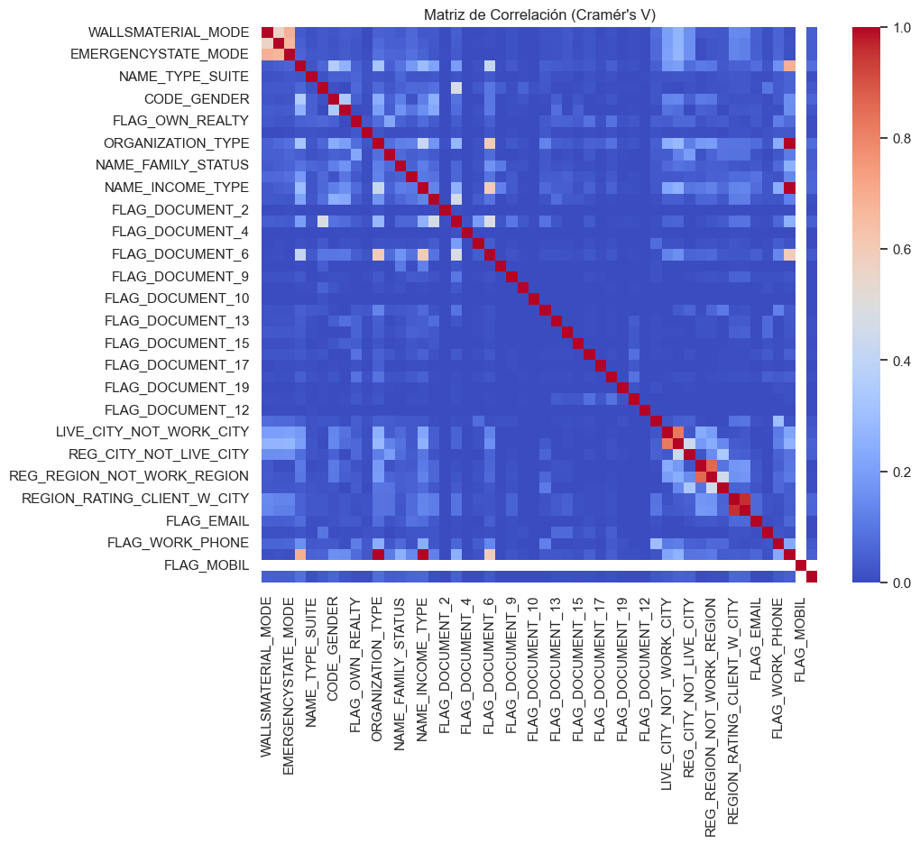

```
Pares de variables con alta correlación (entre 0.6 y 0.99):

WALLSMATERIAL_MODE ↔ EMERGENCYSTATE_MODE: 0.69
HOUSETYPE_MODE ↔ EMERGENCYSTATE_MODE: 0.67
OCCUPATION_TYPE ↔ FLAG_EMP_PHONE: 0.69
LIVE_CITY_NOT_WORK_CITY ↔ REG_CITY_NOT_WORK_CITY: 0.82
LIVE_REGION_NOT_WORK_REGION ↔ REG_REGION_NOT_WORK_REGION: 0.86
REGION_RATING_CLIENT_W_CITY ↔ REGION_RATING_CLIENT: 0.96
```

```python
from scipy.stats import chi2_contingency
f.cramers_v_heatmap_with_high_corr(df_loan_imputed_train, lista_categoricas_definitivo)
```

### Infernecia

Estas relaciones destacan posibles redundancias y asociaciones importantes entre variables. Algunas de estas correlaciones sugieren que ciertas variables podrían ser proxies de fenómenos similares (como REGION_RATING_CLIENT_W_CITY ↔ REGION_RATING_CLIENT o LIVE_REGION_NOT_WORK_REGION ↔ REG_REGION_NOT_WORK_REGION), mientras que otras, como OCCUPATION_TYPE ↔ FLAG_EMP_PHONE, capturan características complementarias a tener en cuenta más tarde.

Es difícil sacar conclusiones de aquí debido a la alta cantidad de variables, además dado que las variables booleanas tienen solo dos categorías, es menos probable que muestren correlaciones fuertes con otras variables categóricas que tienen muchas categorías.

He decidido separar las variables categóricas en booleanas y categóricas no booleanas para simplificar y optimizar el análisis. Las variables booleanas, al tener únicamente dos valores (por ejemplo, Sí/No o 0/1), suelen representar características binarias específicas y se comportan de manera distinta en los modelos y análisis estadísticos. Esto permite tratarlas de forma separada, ya que no necesitan transformaciones adicionales y su interpretación es directa.

Por otro lado, las variables categóricas no booleanas tienen más de dos categorías y requieren un enfoque diferente, como la codificación mediante técnicas como one-hot encoding o embeddings, dependiendo del modelo que se utilice. Al dividirlas, puedo:

Adaptar mejor el preprocesamiento a las características de cada tipo de variable. Evitar redundancias en el tratamiento, ya que muchas veces las booleanas pueden ser directamente utilizadas sin cambios. Facilitar la interpretación del análisis, ya que las correlaciones, relaciones y su importancia en el modelo pueden variar según el tipo de variable. Esta separación también contribuye a mantener un flujo de trabajo más claro y organizado, donde cada grupo de variables puede recibir el tratamiento más adecuado para su naturaleza y función dentro del análisis.

```python
# Crear listas para variables booleanas y categóricas no booleanas
booleanas = []
categoricas_no_booleanas = []

for col in lista_categoricas_definitivo:
    if df_loan_imputed_train[col].nunique() == 2:
        booleanas.append(col)  # Si tiene 2 valores únicos, es booleana
    else:
        categoricas_no_booleanas.append(col)  # Si tiene más de 2 valores, es categórica no booleana

# Ver las listas resultantes
print("Booleanas:", booleanas)
print("Categóricas no booleanas:", categoricas_no_booleanas)
```

```
Booleanas: ['NAME_CONTRACT_TYPE', 'FLAG_OWN_CAR', 'FLAG_OWN_REALTY', 'FLAG_DOCUMENT_8', 'FLAG_DOCUMENT_2', 'FLAG_DOCUMENT_3', 'FLAG_DOCUMENT_4', 'FLAG_DOCUMENT_5', 'FLAG_DOCUMENT_6', 'FLAG_DOCUMENT_7', 'FLAG_DOCUMENT_9', 'FLAG_DOCUMENT_21', 'FLAG_DOCUMENT_10', 'FLAG_DOCUMENT_11', 'FLAG_DOCUMENT_13',…
Categóricas no booleanas: ['WALLSMATERIAL_MODE', 'HOUSETYPE_MODE', 'EMERGENCYSTATE_MODE', 'OCCUPATION_TYPE', 'NAME_TYPE_SUITE', 'CODE_GENDER', 'WEEKDAY_APPR_PROCESS_START', 'ORGANIZATION_TYPE', 'NAME_HOUSING_TYPE', 'NAME_FAMILY_STATUS', 'NAME_EDUCATION_TYPE', 'NAME_INCOME_TYPE', 'REGION_RATING_CLIEN…
```

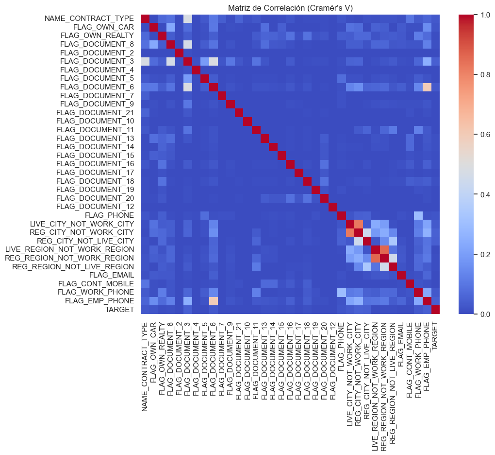

```
Pares de variables con alta correlación (entre 0.6 y 0.99):

LIVE_CITY_NOT_WORK_CITY ↔ REG_CITY_NOT_WORK_CITY: 0.82
LIVE_REGION_NOT_WORK_REGION ↔ REG_REGION_NOT_WORK_REGION: 0.86
```

```python
f.cramers_v_heatmap_with_high_corr(df_loan_imputed_train, booleanas)
```

### Inferencia variables booleanas

En el análisis de las variables booleanas, no se observan diferencias significativas entre las categorías. Esto era de esperarse, ya que este tipo de variables solo tiene dos posibles valores (1 o 0), lo que genera una relación más dicotómica y, en la mayoría de los casos, una correlación baja o inexistente con otras variables. Es decir, la naturaleza binaria de estas variables hace que, en muchos casos, las relaciones entre ellas no aporten información relevante para el análisis o para predecir la variable objetivo.

Entre las variables booleanas, destacan las correlaciones significativas entre LIVE_CITY_NOT_WORK_CITY y REG_CITY_NOT_WORK_CITY (0.82), así como entre LIVE_REGION_NOT_WORK_REGION y REG_REGION_NOT_WORK_REGION (0.86). Ambas parecen representar conceptos similares, relacionadas con la discrepancia entre el lugar de residencia, el trabajo y la dirección registrada del cliente.

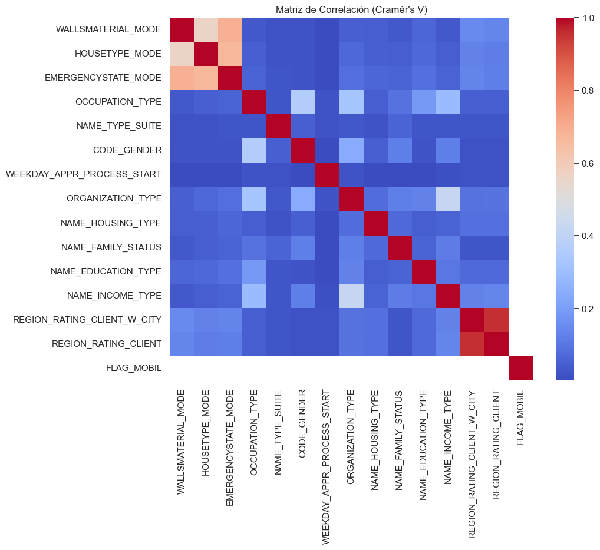

```
Pares de variables con alta correlación (entre 0.6 y 0.99):

WALLSMATERIAL_MODE ↔ EMERGENCYSTATE_MODE: 0.69
HOUSETYPE_MODE ↔ EMERGENCYSTATE_MODE: 0.67
REGION_RATING_CLIENT_W_CITY ↔ REGION_RATING_CLIENT: 0.96
```

```python
f.cramers_v_heatmap_with_high_corr(df_loan_imputed_train, categoricas_no_booleanas)
```

La relación observada entre WALLSMATERIAL_MODE y EMERGENCYSTATE_MODE, con una correlación de 0.69, hay que leerla con cuidado. Según la descripción de las columnas, las dos variables describen el edificio donde vive el cliente: EMERGENCYSTATE_MODE indica si el edificio está en estado de emergencia, no la situación financiera del cliente. Además, gran parte de la correlación viene de los valores faltantes: en el 47% de las filas las dos valen 'sin_valor' (falta toda la información del edificio), y si quitamos esas filas la V de Cramér baja a 0.32. Aun así, el material de las paredes sí puede reflejar en parte el nivel socioeconómico de los clientes: en el notebook 01 vimos que las viviendas de madera tienen más impagos.

En el caso de la relación entre HOUSETYPE_MODE y EMERGENCYSTATE_MODE, con una correlación de 0.67, pasa lo mismo pero más acusado: sin las filas 'sin_valor' la V de Cramér es prácticamente 0 (0.03), así que la relación se debe casi por completo a que la información del edificio falta a la vez en las dos variables. En cuanto al riesgo, los bloques de pisos tienen menos impagos (7.0%) que las viviendas 'specific housing' (10.6%) o las adosadas (9.0%), lo que coincide con el WoE que calculo más abajo. Este vínculo resalta cómo las características de la vivienda pueden ser un indicador indirecto del perfil económico del cliente, aunque débil.

Por último, la relación entre REGION_RATING_CLIENT_W_CITY y REGION_RATING_CLIENT, con una correlación extremadamente alta de 0.96, indica que estas variables miden prácticamente lo mismo. Ambas variables reflejan una evaluación del cliente basada en su región, pero con diferencias menores posiblemente relacionadas con si vive en áreas urbanas o rurales. Dado su alto nivel de redundancia, sería recomendable eliminar una de estas variables del modelo, ya que mantener ambas no aportaría información adicional significativa y podría complicar innecesariamente el análisis.

En conjunto, estas relaciones muestran cómo las características del entorno y las viviendas de los clientes pueden aportar algo de información sobre su perfil financiero, mientras que otras variables redundantes, como las calificaciones regionales, pueden ser simplificadas para mejorar la eficiencia del modelo.

```python
confusion_matrix = pd.crosstab(df_loan_imputed_train["TARGET"], df_loan_imputed_train["HOUSETYPE_MODE"])
print(confusion_matrix)
f.cramers_v(confusion_matrix.values)
```

```
HOUSETYPE_MODE  block of flats  sin_valor  specific housing  terraced house
TARGET
0                       112116     112107              1056             869
1                         8389      11260               125              86
```

```
0.039994748655117034
```

```python
confusion_matrix = pd.crosstab(df_loan_imputed_train["TARGET"], df_loan_imputed_train["OCCUPATION_TYPE"])
print(confusion_matrix)
f.cramers_v(confusion_matrix.values)
```

```
OCCUPATION_TYPE  Accountants  Cleaning staff  Cooking staff  Core staff  \
TARGET
0                       7514            3362           4276       20671
1                        379             372            507        1410

OCCUPATION_TYPE  Drivers  HR staff  High skill tech staff  IT staff  Laborers  \
TARGET
0                  13195       436                   8584       389     39540
1                   1699        28                    560        32      4652

OCCUPATION_TYPE  Low-skill Laborers  Managers  Medicine staff  \
TARGET
0                              1383     16048            6342
1                               296      1092             454

OCCUPATION_TYPE  Private service staff  Realty agents  Sales staff  \
TARGET
0                                 1992            549        23201
1                                  136             44         2446

OCCUPATION_TYPE  Secretaries  Security staff  Waiters/barmen staff  sin_valor
TARGET
0                        993            4751                   959      71963
1                         74             585                   115       4979
```

```
0.08020908712659226
```

# EXTRA

## Weight of Evidence (WoE)

El Weight of Evidence (WoE) mide la relación entre una categoría de una variable independiente y una variable objetivo binaria. Es útil para evaluar la capacidad predictiva de una categoría y se calcula como:

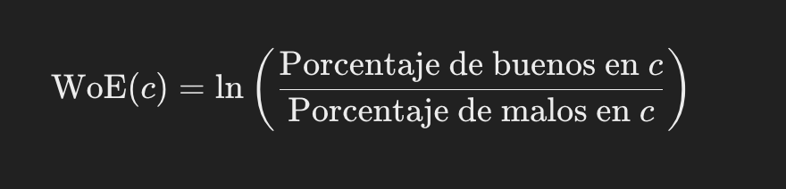

Donde:

- Buenos (Good): Representan el valor 0 en la variable objetivo.
- Malos (Bad): Representan el valor 1 en la variable objetivo.

El WoE transforma las categorías en valores numéricos que son interpretables:

- Valores positivos indican que una categoría está más asociada con buenos (menos riesgo).
- Valores negativos indican que está más asociada con malos (más riesgo).

## Information Value (IV)

El Information Value (IV) cuantifica la capacidad predictiva de una variable completa, evaluando cuánto discrimina entre buenos y malos. Se calcula como:

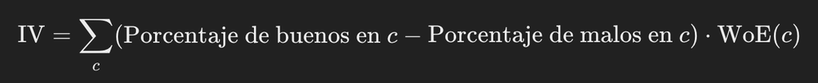

Rango del IV:

- < 0.02: Sin valor predictivo.
- 0.02 - 0.1: Bajo valor predictivo.
- 0.1 - 0.3: Moderado valor predictivo.
- '> 0.3: Alto valor predictivo.

```python
woe_table1, iv1 = f.calculate_woe_iv(df_loan_train, feature='CODE_GENDER', target='TARGET')
woe_table2, iv2 = f.calculate_woe_iv(df_loan_train, feature='NAME_INCOME_TYPE', target='TARGET')
woe_table3, iv3 = f.calculate_woe_iv(df_loan_train, feature='HOUSETYPE_MODE', target='TARGET')

print(woe_table1)
print(f"Information Value (IV) total: {iv1}")

print('-------------------------------------------------------------')

print(woe_table2)
print(f"Information Value (IV) total: {iv2}")

print('-------------------------------------------------------------')

print(woe_table3)
print(f"Information Value (IV) total: {iv3}")
```

```
             good_dist  bad_dist        WoE        IV
CODE_GENDER
F             0.665816  0.569335   0.156544  0.015103
M             0.334171  0.430665  -0.253678  0.024478
XNA           0.000013  0.000000  11.795518  0.000156
Information Value (IV) total: 0.03973843093431426
-------------------------------------------------------------
                      good_dist  bad_dist        WoE        IV
NAME_INCOME_TYPE
Businessman            0.000044  0.000000  12.999491  0.000575
Commercial associate   0.234700  0.217724   0.075081  0.001275
Maternity leave        0.000013  0.000050  -1.333870  0.000049
Pensioner              0.184680  0.119184   0.437953  0.028684
State servant          0.072435  0.051611   0.338948  0.007058
Student                0.000057  0.000000  13.261855  0.000762
Unemployed             0.000057  0.000252  -1.476971  0.000287
Working                0.508012  0.611178  -0.184883  0.019074
Information Value (IV) total: 0.057763886123003275
-------------------------------------------------------------
                  good_dist  bad_dist       WoE        IV
HOUSETYPE_MODE
block of flats      0.98312  0.975465  0.007817  0.000060
specific housing    0.00926  0.014535 -0.450866  0.002378
terraced house      0.00762  0.010000 -0.271800  0.000647
Information Value (IV) total: 0.003085048186357519
```

1. CODE_GENDER La variable tiene un IV bajo (0.0397), indicando bajo poder predictivo. Las mujeres (F) están asociadas con menor riesgo (WoE: 0.1565), mientras que los hombres (M) tienen mayor riesgo relativo (WoE: -0.2537). La categoría XNA tiene un WoE extremo, pero su baja frecuencia la hace irrelevante.
2. NAME_INCOME_TYPE Con un IV de 0.0578, todavía en el rango bajo pero por encima de la anterior, esta variable aporta más valor predictivo. Las categorías Pensioner (WoE: 0.4380) y State servant (WoE: 0.3389) están asociadas con menor riesgo, mientras que Working (WoE: -0.1849) muestra mayor riesgo relativo. Categorías como Student o Businessman tienen WoEs altos por baja frecuencia, con impacto mínimo.
3. HOUSETYPE_MODE El IV es muy bajo (0.0031), lo que indica que la variable no es relevante para discriminar entre "buenos" y "malos". Las categorías Specific housing (WoE: -0.4509) y Terraced house (WoE: -0.2718) muestran un leve mayor riesgo, pero el impacto general es insignificante.

# 4. Guardado de tablas

```python
df_loan_imputed_train.to_csv('../data/processed_data/train_data_processed.csv', index=False)
df_loan_imputed_test.to_csv('../data/processed_data/test_data_processed.csv', index=False)
```